# Instructor Notes 3: Exploratory Data Analysis II

Randi H. Griffin

# Introduction

These notes focus on inspecting multivariate relationships between variables and transforming data based on these inspections, including an introduction to using PCA and K-Means clustering for exploration and feature engineering.

This is where things start to get interesting! We want to test our predictions about the data and identify the features that are most likely to contribute to predictive modeling. Multivariate plots give us our first peek at the answers to these questions.

Multivariate plots also help us to identify additional data cleaning steps and ideas for feature engineering. It is never to late to loop back and add additional data cleaning steps as you discover problems in the data.

## Motivating example

I will use R’s built-in `diamonds` dataset as an example throughout these notes. The dataset on diamond prices invites us to predict the target variable `price` as a function of different characteristics of the diamond, including weight (`carat`), quality (`cut`), `color`, `clarity`, dimensions (`x`, `y`, and `z`), `depth`, and relative width of the top to the widest point (`table`):

```r
# Load libraries
library('tidyverse')
library('knitr')
library('gridExtra')
library('factoextra')

# Inspect data
diamonds %>% summary
```

```
##      carat               cut        color        clarity
##  Min.   :0.2000   Fair     : 1610   D: 6775   SI1    :13065
##  1st Qu.:0.4000   Good     : 4906   E: 9797   VS2    :12258
##  Median :0.7000   Very Good:12082   F: 9542   SI2    : 9194
##  Mean   :0.7979   Premium  :13791   G:11292   VS1    : 8171
##  3rd Qu.:1.0400   Ideal    :21551   H: 8304   VVS2   : 5066
##  Max.   :5.0100                     I: 5422   VVS1   : 3655
##                                     J: 2808   (Other): 2531
##      depth           table           price             x
##  Min.   :43.00   Min.   :43.00   Min.   :  326   Min.   : 0.000
##  1st Qu.:61.00   1st Qu.:56.00   1st Qu.:  950   1st Qu.: 4.710
##  Median :61.80   Median :57.00   Median : 2401   Median : 5.700
##  Mean   :61.75   Mean   :57.46   Mean   : 3933   Mean   : 5.731
##  3rd Qu.:62.50   3rd Qu.:59.00   3rd Qu.: 5324   3rd Qu.: 6.540
##  Max.   :79.00   Max.   :95.00   Max.   :18823   Max.   :10.740
##
##        y                z
##  Min.   : 0.000   Min.   : 0.000
##  1st Qu.: 4.720   1st Qu.: 2.910
##  Median : 5.710   Median : 3.530
##  Mean   : 5.735   Mean   : 3.539
##  3rd Qu.: 6.540   3rd Qu.: 4.040
##  Max.   :58.900   Max.   :31.800
##
```

For illustrative purposes, I engineer a binary variable called `high_price` indicating whether the price of the diamond is above the median price. This will allow me to make plots with a binary version of the target variable.

```r
# Create binary version of price variable
diamonds$high_price <- ifelse(diamonds$price > median(diamonds$price), 1, 0)

# Inspect with a table
diamonds$high_price %>% table
```

```
## .
##     0     1
## 26985 26955
```

## Multivariable Inspect-Transform-Inspect workflow (ITI)

In comparison to single variable ITI, there are many possibilities for multivariable plotting, so it is important to approach this portion of the project with a clear vision of what you are looking for. Here is an overview of the workflow for multivariate relationships:

1. Inspect each `target ~ predictor` relationship. Does the relationship align with your expectations? Is the feature likely to be useful for predictive modeling? Are transformations needed?
2. Check for high-dimensionality
   - 2a. IF you have **multiple continuous predictors**, check their correlations by visualizing pairwise relationships and correlations. If strong multicollinearity is present, consider dropping variables or reducing dimensionality with PCA.
   - 2b. IF you have **categorical predictor(s) with sparse levels** (e.g., less than 20 examples of a given category), devise a way to combine rare categories into larger groups.
3. Perform transformations based on the inspections above.
4. Plot a final set of post-transformation `target ~ predictor` relationships before modeling.

In addition, you may end up making *ad hoc* inspections to follow up on interesting observations or questions raised by your exploration.

## Bivariate plots

Previously, we inspected individual continuous variables with histograms and categorical variables with tables or barplots. Now we want to visually inspect the relationships between *pairs* of variables with two-way, or bivariate plots. These are the simplest types of multivariate plots.

Bivariate plots are defined by which type of variable, continuous or categorical, is on the x and y axes. The most common types of bivariate plots include:

- **Scatterplots:** A pair of continous features are represented as points in 2D.
- **Boxplots:** Each box shows the distribution of a continuous variable, multiple boxes represent different categories.
- **Grouped density plot:** This is useful for showing how density plots (similar to histograms) for a continuous variable differ across two or three categories.
- **Side-by-side/Stacked barplots:** Each bar represents counts or propoportions of a given category.

Examples of each plot is shown below. I log transform `price` and `caret` since they have right-skewed distributions (not shown here):

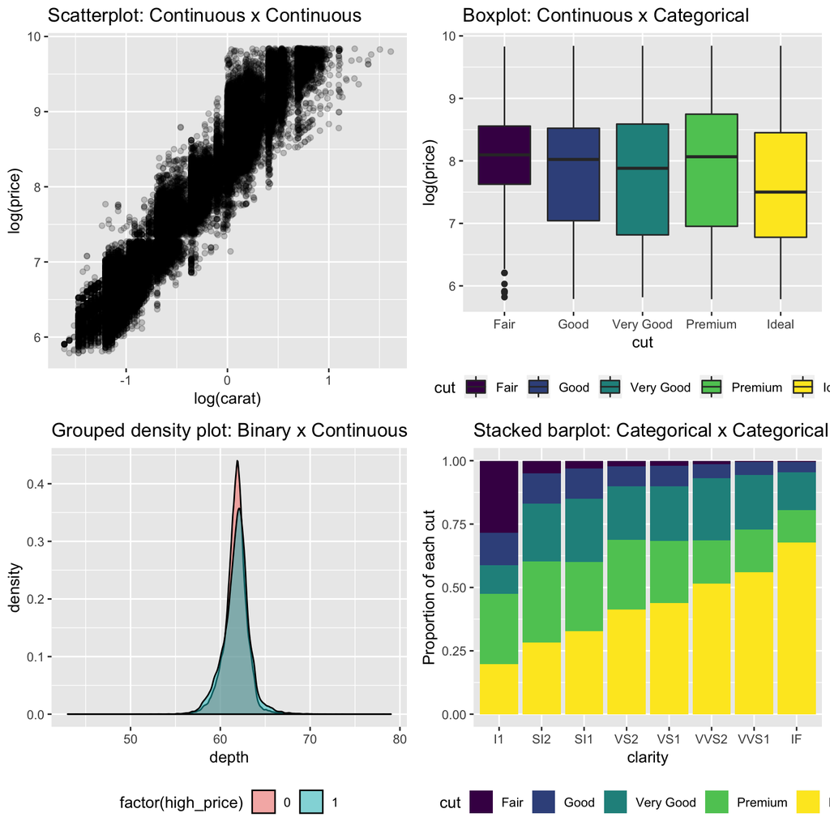

```r
# Scatterplot
g1 <- diamonds %>%
  ggplot(aes(x=log(carat), y=log(price))) +
  geom_point(alpha=0.2) +
  ggtitle('Scatterplot: Continuous x Continuous')

# Boxplot
g2 <- diamonds %>%
  ggplot(aes(x=cut, y=log(price), fill=cut)) +
  geom_boxplot() +
  ggtitle('Boxplot: Continuous x Categorical') +
  theme(legend.position="bottom")

# Grouped density plot (similar to histograms)
g3 <- diamonds %>%
  ggplot(aes(x=depth, fill=factor(high_price))) +
  geom_density(alpha=0.5) +
  ggtitle('Grouped density plot: Binary x Continuous') +
  theme(legend.position="bottom")

# Barplot (proportions, stacked)
g4 <- diamonds %>%
  ggplot(aes(x=clarity, fill=cut)) +
  geom_bar(position = 'fill') +
  ggtitle('Stacked barplot: Categorical x Categorical') +
  ylab('Proportion of each cut') +
  theme(legend.position="bottom")
grid.arrange(g1, g2, g3, g4, ncol=2)
```

Be sure you understand how to read these plots. Take a few moments to describe what each of the plots above tells us about the `diamonds` dataset:

These plot types cover many common situations, however there will come a point where they are not enough. Don’t panic! R and `ggplot` are versatile and the community is incredibly helpful. Think about the plot you want to make and find the words the describe it. Chances are, someone has been in your situation before and a well-posed Google search will lead you to a solution.

# Transformations

The insights gleaned from your bivariate plots can be roughly broken down into two categories:

1. Insights about which predictor variables are useful for modeling
   - If a predictor has no relationship or a complex relationship with your target, it will be challenging to model, so consider dropping it from the analysis
2. Insights about possible problems or challenges, including:
   - Outliers or missing/incorrect data
   - Non-linear relationships
   - Sparse categorical features
   - Multicollinear continuous features
   - Hidden groupings

If outliers or missing data appear in the multivariable inspection stage, treat them as before: Try to understand why they exist and decide whether to throw them away or replace them with reasonable values. The other problems receive a more in-depth treatment below.

## Problem: Non-linear relationships

**What is non-linearity:** Non-linearity arises when the relationship between a continuous target and a continuous or ordinal predictor is not a straight line, but rather a curve of some type.

**Why is non-linearity a problem:** Linear models assume that the relationship between the target and predictors can be modeled with a straight line, and violating this assumption leads to poor model performance.

**Visual examples:** The following plots show examples of linearity (top) and non-linearity (bottom) for a continuous target variable plotted against a continuous predictor (left) and an ordinal predictor (right):

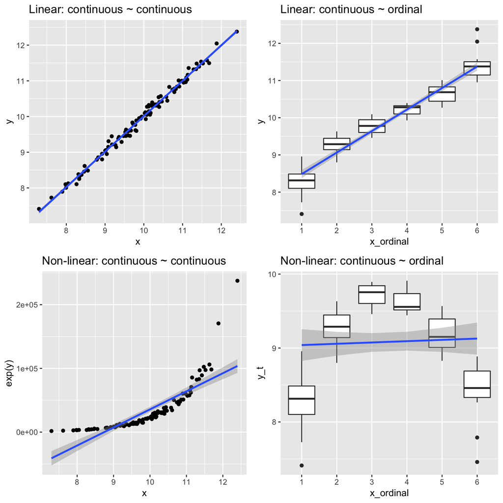

```r
# Simulate data
set.seed(37)
n <- 100
x <- 10 + rnorm(n)
x_ordinal <- ntile(x, 6)
y <- x + rnorm(n, sd=0.1)
df <- data.frame(y = y, x = x, x_ordinal = factor(x_ordinal))

# Continuous vs continuous: linear
g1 <- df %>% ggplot(aes(x=x,y=y)) +
  geom_point() +
  geom_smooth(method = 'lm', se=TRUE) +
  ggtitle('Linear: continuous ~ continuous')

# Continuous vs ordinal: linear
g2 <- df %>% ggplot(aes(x=x_ordinal,y=y)) +
  geom_boxplot() +
  geom_smooth(method = 'lm', se=TRUE, aes(group=1)) +
  ggtitle('Linear: continuous ~ ordinal')

# Continuous vs continuous: non-linear
g3 <- df %>% ggplot(aes(x=x,y=exp(y))) +
  geom_point() +
  geom_smooth(method = 'lm', se=TRUE) +
  ggtitle('Non-linear: continuous ~ continuous')

# Continuous vs ordinal: non-linear
g4 <- df %>% mutate(y_t = ifelse(y > mean(y), y - 2*(y - mean(y)), y)) %>%
  ggplot(aes(x=x_ordinal,y=y_t)) +
  geom_boxplot() +
  geom_smooth(method = 'lm', se=TRUE, aes(group=1)) +
  ggtitle('Non-linear: continuous ~ ordinal')

grid.arrange(g1, g2, g3, g4, ncol=2)
```

### Solution: Power transforms or binning

There is no one-size fits all solution to fixing non-linearities.

With a continuous vs continuous relationship, the most common cause of non-linearity is one or more of the variables being skewed or otherwise non-normally distributed. Thus, you can fix these probems by transforming the individual variables to have a normal distribution. For example, the non-linearity above (bottom left plot) occurs because the target variable is right skewed and needs to be log transformed.

With a continuous vs ordinal relationship (bottom right plot), non-linearity can be solved by binning the ordinal variable into a reduced number of levels, e.g., into binary ‘high’ and ‘low’ levels. The downside of binning is that it throws away information by reducing a granular variable into a crude binary one, but if your distribution is highly non-linear, binning is your last ditch option for eliminating the problem.

## Problem: Sparse categorical features

**What are sparse categories:** A sparse category is a level of a categorical variable that has very few examples in your data.

**Why are sparse categories a problem:** To understand why this is a problem, it helps to realize that nearly all ML and statistical models, including linear and logistic regression, convert categorical variables into a set of dummy variables under the hood. Dummy variables encode the presence/absence of each level of the category as binary variables. For instance, if you have a categorical variable called ‘Animal’ with the 3 categories ‘dog’, ‘cat’, and ‘cow’, this would be converted into 3 dummy variables as follows:

```r
set.seed(37)

# Create original categorical variable
df <- data.frame(Animal = sample(c('dog','cat','cow'), 10, replace=TRUE))

# Create dummy variables for each level of the categorical variable
df$dog_dummy <- ifelse(df$Animal == 'dog', 1, 0)
df$cat_dummy <- ifelse(df$Animal == 'cat', 1, 0)
df$cow_dummy <- ifelse(df$Animal == 'cow', 1, 0)

# View table
kable(df)
```

| Animal | dog_dummy | cat_dummy | cow_dummy |
| --- | --- | --- | --- |
| cat | 0 | 1 | 0 |
| dog | 1 | 0 | 0 |
| cat | 0 | 1 | 0 |
| cat | 0 | 1 | 0 |
| cow | 0 | 0 | 1 |
| cow | 0 | 0 | 1 |
| cat | 0 | 1 | 0 |
| cat | 0 | 1 | 0 |
| dog | 1 | 0 | 0 |
| dog | 1 | 0 | 0 |

Notice that for every row where `Animal = dog`, the `dog_dummy` column has a 1, otherwise it has a 0. The same is true for `cat_dummy` and `cow_dummy`. When a categorical variable with `k` levels goes into a linear or logistic regression, it actually gets converted into `k - 1` dummy variables, with one of the categories being considered the ‘baseline’ that each other categories get compared to. The resulting model will have `k - 1` regression coefficients, each estimating the effect of a single category relative to the baseline category.

It follows that categories with sparse data (e.g., fewer than 20 observations) cannot be modeled with confidence. Moreover, from the perspective of the model, categorical variables with many categories can add *a lot* of complexity to models. Unnecessary complexity contributes to [overfitting](https://en.wikipedia.org/wiki/Overfitting), or producing an overly specific model that captures random noise in the data and will not generalize well to new datasets. Overfitting is bad for BOTH model interpretability and predictive performance, since it leads to parameters modeling random noise rather than generalizable patterns.

### Solution: Grouping rules

Given the discussion above, it is a good idea to keep this complexity as minimal as possible: Include only categories that add meaningful information to the model and eliminate sparse categories that cannot be modeled with confidence. But how can we combine sparse categories? It depends on the situation. Here is a non-exhaustive list of possibilities:

- Combine all categories with fewer than *n* data points into a `rare_category` group.
- Apply domain knowledge to come up with a sensible grouping of the categories (e.g., grouping countries into geographic regions).
- Define categories with respect to some independent variable (e.g., clustering countries based on population size and GDP).

The important thing is to recognize excessive or sparse categories and devise a sensible rule to reduce the dimensionality of your categorical variables. Once you have devised a rule, functions such as `ifelse`, `case_when`, and `recode` may be helpful for engineering the new categorical variable.

## Problem: Multicollinear continuous features

**What is multicollinearity:** Multicollinearity is a technical term for having highly correlated continuous predictor variables. As a rule of thumb, predictor variables with correlations greater than 0.8 deserve concern.

**Why multicollinearity matters:** Both linear and logistic regression assume that predictor variable contribute *independent information* to model predictions. Multicollinearity violates this assumption by introducing highly correlated variables that contain redundant information (which is the opposite of independent information). Multicollinearity results in models that are impossible to interpret and make unreliable predictions, so it is critical to detect and remove it before doing predictive modeling.

**Intuitive example:** Imagine we are trying to predict how tall babies will grow based on the length of their feet at birth. The right and left foot may differ slightly, but both feet are expected to be equally predictive of growth. The models `height ~ left foot` and `height ~ right foot` may produce nearly identical results that show a positive relationship between foot length and height. However, the model `height ~ left foot + right foot` is likely to produce wildly different estimates of the relationship for each foot. Changing the input data slightly could cause the relationships for each foot to fluctuate wildly, even swinging in the opposite direction. This pathological model behavior arises because the model cannot easily differentiate the influence of each foot on the target variable, since the contribute essentially the same information.

Ultimately, there are two reasons to avoid multicollinearity, one related to interpretation and the other related to predictive performance:

1. **Interpretation problem:** When you have highly correlated predictor variables, models have a hard time differentiating their effects on the target variable. It causes regression coefficients to be extremely unstable and sensitive to small changes to the data, rendering regression coefficients uninterpretable.
2. **Predictive accuracy problem:** Since highly correlated features contain redundant information, the estimated regression coefficients are at risk of capturing random noise in the dataset, leading to a model that performs well within the training data but does not generalize well to new datasets (also known as [overfitting](https://en.wikipedia.org/wiki/Overfitting)).

Since we will be using linear or logistic regression in our projects, we need to check for multicollinearity and address it if it is a problem. To check for multicollinearity, my preferred approach is to use the `pairs.panel` function from the `psych` package. I like this function because you can see scatterplots, correlations, and histograms of the continuous variables all in a single plot. Thus, this one plot can satisfy all of your needs for single and multivariable EDA of continuous variables!

Let’s check the correlations among the continuous variables in the `diamonds` dataset for multicollinearity. Note that I only include the continuous predictor variables in the input dataframe:

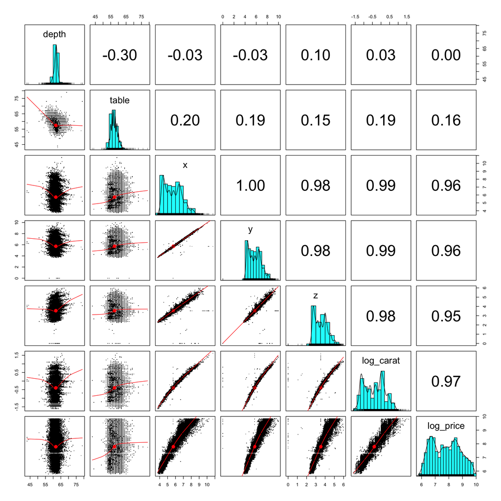

```r
# load psych library (must install it first)
library('psych')

# Log transform skewed variables, remove outliers, and isolate continuous variables
diamonds_cont <- diamonds %>%
  mutate(log_carat = log(carat),
         log_price = log(price),
         table = ifelse(table > 80, median(table), table),
         x = ifelse(x < 3, median(x), x),
         y = ifelse(y > 10, median(y), y),
         z = ifelse(z > 6, median(z), z)
         ) %>%
  select(-carat, -price, -cut, -color, -clarity, -high_price)

# View pairs plot
pairs.panels(diamonds_cont, pch=".")
```

What we see is several very strong correlations: `x`, `y`, `z`, and `log_carat` are extremely tightly correlated (*r* > 0.97), indicating that we have extreme multicollinearity.

**Note:** If you have too many points (e.g., more than 100-200), the scatterplots in the `pairs.panels` plot may become overly crowded, making it difficult to see the underlying relationship. You can make the points very small by adding the argument `pch="."`.

You can also use the built in R functions `cor` and `pairs` to get the same information, but less neatly packaged

Now that we know there is multicollinearity, we can address it in one of three ways:

1. **Selectively dropping collinear variables.** This is the simplest approach. Ideally, you should have some justification for how you choose which variable(s) to keep. Perhaps one of the variables leads to more accurate predictions, or perhaps one variable has less missing data or fewer outliers.
2. **Combining collinear variables in some way (e.g., averaging them).** Imagine you have scores on 10 different tests from students in a course, so each test is a column in your data. Assuming all the test scores are on the same scale (e.g., 0-100%), you could create a new ‘average test score’ variable for each student to replace the multiple columns of test scores.
3. **Perform dimension reduction with PCA.** PCA creates new mathematical combinations of the original variables, ensuring that the new variables (or ‘Principal Components’, PCs) are uncorrelated and sorted in order of how much variation they explain in the original variables. A subset of the most important PCs can be retained in downstream analysis in place of the original variables. Since PCs are uncorrelated by definition, they cannot suffer from multicollinearity.

Since the first two approaches don’t require any new code or concepts, let’s focus on PCA.

### Solution: PCA dimension reduction

If you need a refresher on the basics of PCA, review the section on PCA in [Instructor notes 1](http://www.randigriffin.com/assets/teaching_materials/Instructor_Notes_1.html). The basic idea is that PCA takes *N* continuous input features, scales and rotates them to produce *N* new uncorrelated features called ‘PCs’ which explain decreasing amounts of variation in the data, and then discards the least important PCs while retaining the most informative PCs (this last step reduces the dimensionality of the data, which is why this is called a ‘dimension reduction’). Our focus here will be on deciding how many PCs to keep from PCA.

The most common heuristic for choosing the number of PCs is to use a [skree plot](https://en.wikipedia.org/wiki/Scree_plot). A skree plot shows how quickly the sum of squares explained by each PC declines with each subsequent PC, with ‘importance’ being measured by the proportion of variance in the original data that is explained by each PC. What people typically look for is the ‘point of diminishing returns’, or the ‘elbow’ of the curve, because this is the point at which adding more PCs is expected to have a diminishing benefit.

Let’s perform PCA on our `diamonds` dataset:

```r
# drop target variable, log_price
diamonds_pca <- diamonds_cont %>% select(-log_price)

# Fit PCA model (variable scaling occurs automatically)
pc_model <- diamonds_pca %>% prcomp

# View PC variables
head(pc_model$x) %>% kable
```

| PC1 | PC2 | PC3 | PC4 | PC5 | PC6 |
| --- | --- | --- | --- | --- | --- |
| 3.1112099 | -2.169226 | -0.5692077 | 0.0479350 | 0.0703376 | -0.0974578 |
| -2.7421936 | -4.309881 | -0.2744978 | 0.0709613 | 0.0346231 | -0.1472827 |
| -7.2178818 | -5.773027 | -1.7969661 | 0.1204037 | 0.0232245 | -0.0863784 |
| 0.4515084 | -2.311599 | 1.1426641 | 0.0261992 | 0.0526698 | -0.0412395 |
| 0.6075276 | -1.890011 | 1.9551075 | 0.0194400 | 0.0635142 | -0.0645038 |
| 1.6070592 | -2.373624 | 1.2720466 | 0.0335736 | 0.0780317 | -0.0884682 |

```r
# Check correlations between PC variables
cor(pc_model$x) %>% kable
```

|  | PC1 | PC2 | PC3 | PC4 | PC5 | PC6 |
| --- | --- | --- | --- | --- | --- | --- |
| PC1 | 1 | 0 | 0 | 0 | 0 | 0 |
| PC2 | 0 | 1 | 0 | 0 | 0 | 0 |
| PC3 | 0 | 0 | 1 | 0 | 0 | 0 |
| PC4 | 0 | 0 | 0 | 1 | 0 | 0 |
| PC5 | 0 | 0 | 0 | 0 | 1 | 0 |
| PC6 | 0 | 0 | 0 | 0 | 0 | 1 |

You can see that PCA took the original 6 continuous variables and transformed them into 6 new continuous variables, or PCs, but unlike the original variables, the PCs have correlations of 0.

Let’s look at the relative ‘importance’ of each new PC with a scree plot to help us decide how many PCs will be useful to keep for downstream analysis:

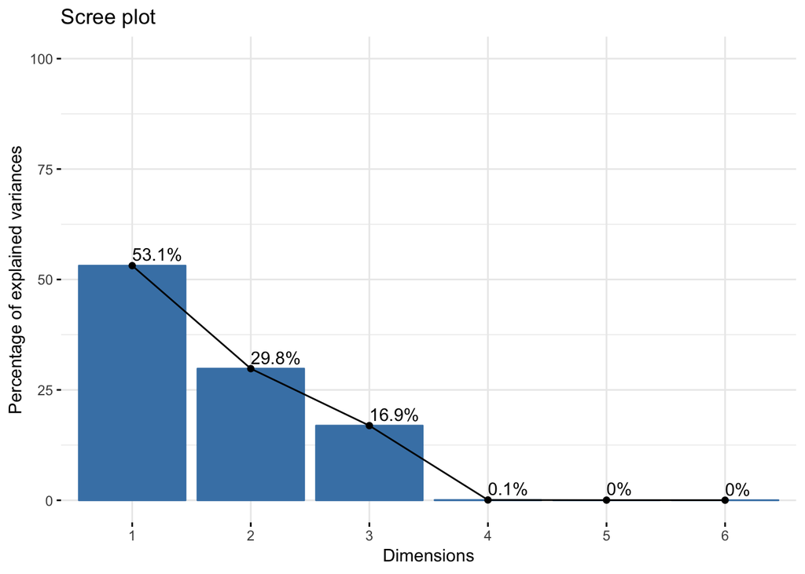

```r
# Visualize scree plot
fviz_screeplot(pc_model, addlabels = TRUE, ylim = c(0, 100))
```

There is a massive drop off after the first 3 PCs (if you look at the line, it is the ‘elbow’ of the line), indicating that additional PCs capture little additional variation in the original variables. In other words, most of the information in the original 6 features can be consolidated into just the first 3 PCs which account for over 99% of the original variance.

Once you have made your selection, the reduced set of PCs can be used as input features for preditive modeling. Here is an example of fitting linear models using the original 6 variables and the 4 top PCs. We could then evaluate these models on a holdout sample to determine which one performs better on an independent dataset.

```r
# Add PC variables to the original dataframe
diamonds_new <- cbind(diamonds_cont, pc_model$x)

# View new dataframe
diamonds_new %>% head %>% kable
```

| depth | table | x | y | z | log_carat | log_price | PC1 | PC2 | PC3 | PC4 | PC5 | PC6 |
| --- | --- | --- | --- | --- | --- | --- | --- | --- | --- | --- | --- | --- |
| 61.5 | 55 | 3.95 | 3.98 | 2.43 | -1.469676 | 5.786897 | 3.1112099 | -2.169226 | -0.5692077 | 0.0479350 | 0.0703376 | -0.0974578 |
| 59.8 | 61 | 3.89 | 3.84 | 2.31 | -1.560648 | 5.786897 | -2.7421936 | -4.309881 | -0.2744978 | 0.0709613 | 0.0346231 | -0.1472827 |
| 56.9 | 65 | 4.05 | 4.07 | 2.31 | -1.469676 | 5.789960 | -7.2178818 | -5.773027 | -1.7969661 | 0.1204037 | 0.0232245 | -0.0863784 |
| 62.4 | 58 | 4.20 | 4.23 | 2.63 | -1.237874 | 5.811141 | 0.4515084 | -2.311599 | 1.1426641 | 0.0261992 | 0.0526698 | -0.0412395 |
| 63.3 | 58 | 4.34 | 4.35 | 2.75 | -1.171183 | 5.814131 | 0.6075276 | -1.890011 | 1.9551075 | 0.0194400 | 0.0635142 | -0.0645038 |
| 62.8 | 57 | 3.94 | 3.96 | 2.48 | -1.427116 | 5.817111 | 1.6070592 | -2.373624 | 1.2720466 | 0.0335736 | 0.0780317 | -0.0884682 |

```r
# Fit linear regression using original 6 variables
lm_raw <- lm(log_price ~ depth + table + log_carat + x + y + z, data=diamonds_new)

# Fit linear regression using first 4 PCs
lm_pca <- lm(log_price ~ PC1 + PC2 + PC3 + PC4, data=diamonds_new)
```

By using the 4 PCs in place of the original 6 variables, we are in fact throwing some information away. The hope is that the information we are throwing away is random noise. How can we be sure this is a good decision?

The only way to be really sure is to systematically compare the accuracy of predictions using each possible number of PCs, but we don’t have the tools to do that yet. We will learn to evaluate and compare model performance in a future set of Instructor notes.

## Problem: Hidden groupings in the data

**What are hidden groupings:** Often, you will suspect that there are hidden groups in your data based on a mixture of data exploration and domain knowledge.

**Why hidden groupings matter:** Identifying clusters can be exciting. It can even be the star of your project if the clusters add insight or serve as new features for modeling. Clusters can add interpretability to results from PCA as well, since PCA will sometimes reveal clusters when you plot PC1 vs PC2.

**Example of hidden clusters:** Let’s look at an example where PCA reveals hidden clusters in the data. The `iris` dataset provides a classic example. This dataset contains 4 measurements of the petal length/width and sepal length/width for individual flowers from 3 different species:

```r
# Check iris dataset
iris %>% summary
```

```
##   Sepal.Length    Sepal.Width     Petal.Length    Petal.Width
##  Min.   :4.300   Min.   :2.000   Min.   :1.000   Min.   :0.100
##  1st Qu.:5.100   1st Qu.:2.800   1st Qu.:1.600   1st Qu.:0.300
##  Median :5.800   Median :3.000   Median :4.350   Median :1.300
##  Mean   :5.843   Mean   :3.057   Mean   :3.758   Mean   :1.199
##  3rd Qu.:6.400   3rd Qu.:3.300   3rd Qu.:5.100   3rd Qu.:1.800
##  Max.   :7.900   Max.   :4.400   Max.   :6.900   Max.   :2.500
##        Species
##  setosa    :50
##  versicolor:50
##  virginica :50
##
##
##
```

Now imagine that we have the measurements, but we don’t know what the species are. If we perform PCA on the 4 continous measurement columns and plot the transformed variables PC1 and PC2, the data clearly fall into at least 2 distinct clusters:

```r
# Perform PCA on iris dataset measurements (drop Species column)
pc_iris <- iris %>% select(-Species) %>% prcomp

# View PC variables
head(pc_iris$x) %>% kable
```

| PC1 | PC2 | PC3 | PC4 |
| --- | --- | --- | --- |
| -2.684126 | -0.3193972 | 0.0279148 | 0.0022624 |
| -2.714142 | 0.1770012 | 0.2104643 | 0.0990266 |
| -2.888991 | 0.1449494 | -0.0179003 | 0.0199684 |
| -2.745343 | 0.3182990 | -0.0315594 | -0.0755758 |
| -2.728716 | -0.3267545 | -0.0900792 | -0.0612586 |
| -2.280860 | -0.7413304 | -0.1686777 | -0.0242009 |

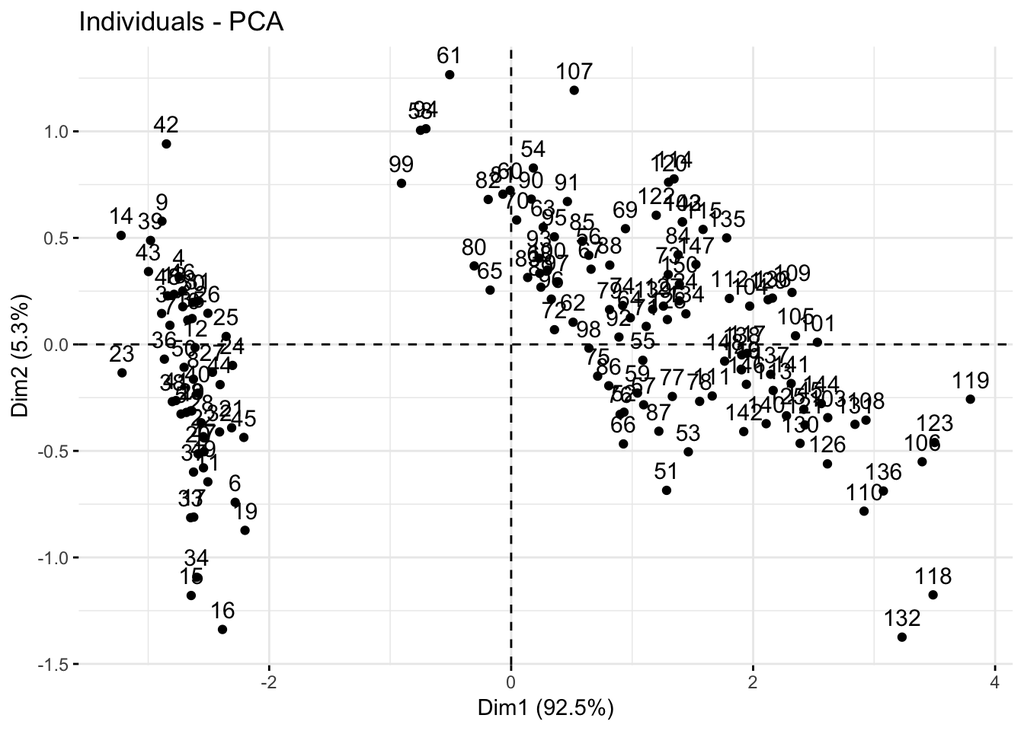

```r
# Visualize data along PC1 and PC2
fviz_pca_ind(pc_iris)
```

Now, we know that these clusters correspond to different flower species. To prove this, here is the exact same plot with the actual flower species indicated by the color of points. We can see that there are actually 3 clusters, but the `setosa` species is much more distinct than `versicolor` and `virginica`:

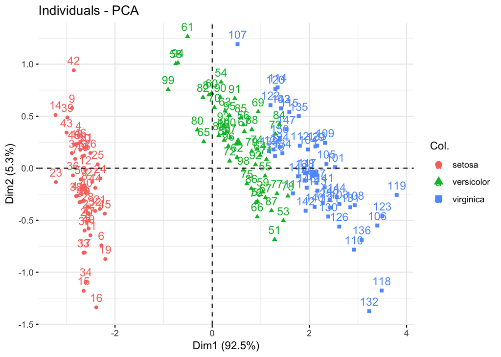

```r
# Visualize data along PC1 and PC2
fviz_pca_ind(pc_iris, col.ind = iris$Species)
```

Imagine we didn’t have knowledge of which species was which. It would be very valuable to have a method that can identify these hidden groups. Let’s see how K-Means clustering can help us label these hidden groups. We can then use the new groupings for further EDA or even as features in predictive models.

### Solution: K-Means Clustering

If you need a refresher on the basics of K-Means Clustering, review the section on K-Means in [Instructor notes 1](http://www.randigriffin.com/assets/teaching_materials/Instructor_Notes_1.html). The idea is that you feed a set of continuous variables into K-Means Clustering and the algorithm finds a pre-specified number of clusters in your data. You can think of clustering as creating as a new categorical variable for your dataset by assigning a cluster ID to each row of input data.

A very important point about K-Means clustering which we have not discussed yet is that it requires the input data to be relatively uncorrelated and standardized. Let’s clarify what this means and why it matters:

- **Inputs should be uncorrelated:** K-Means clustering works by finding the ‘centroid’ or ‘average position’ of each cluster in the multivariate space defined by your input variables. If you have highly correlated input variables that represent redundant information, this redundant information will have an outsized influence on the clustering results. – **Inputs should be standardized:** Standardized variables have a mean of 0 and a standard deviation of 1 (this is achieved by applying the [z-score transformaton](https://en.wikipedia.org/wiki/Standard_score): `y <- (y - mean(y))/sd(y)`). This transformation is critical to ensure that variables with large scales do not have an outsized influence on the clustering results. For example, if I am clustering individuals based on how likely they are to be admitted to an elite university and I have data on their SAT scores (mean 1800, standard deviation 200) and their family income (mean 60000, standard deviation 20000), the income variable is on a much larger scale, so it will contribute more to the clustering results unless we standardize everything to have the same mean and standard deviation.

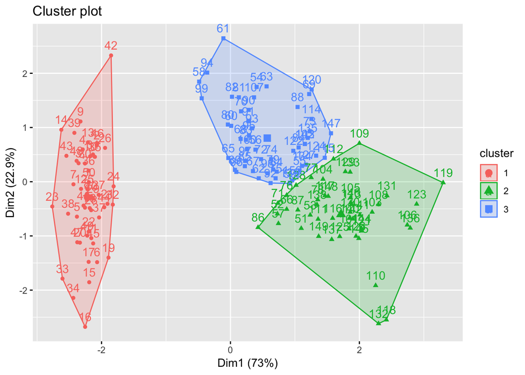

```r
# Drop species variable and standardize with 'scale'
iris_scaled <- iris %>% select(-Species) %>% scale

# Apply k-means clustering with k=3
kmeans_iris <- iris_scaled %>% kmeans(centers=3)

# Visualize results (we have to provide both the clusters and original data)
fviz_cluster(kmeans_iris, iris %>% select(-Species)  %>% scale)
```

It looks like K-Means Clustering found 3 clusters, but are the ‘correct’? We know that the clusters *should* correspond to the Species variable. Let’s see how well they correspond by creating a table that shows the relationship between the clusters from our K-Means model and the original Species variable that we are hoping identify. Note that we can access the cluster IDs with `kmeans_iris$cluster`:

```r
# Do the clusters capture different flower species?
table(iris$Species, kmeans_iris$cluster)
```

```
##
##               1  2  3
##   setosa     50  0  0
##   versicolor  0 11 39
##   virginica   0 36 14
```

Perhaps this means we should be using fewer than 3 clusters. Let’s use a more systematic approach to choosing the number of clusters by making an elbow plot, which is exactly analogous to the scree plot we made for PCA:

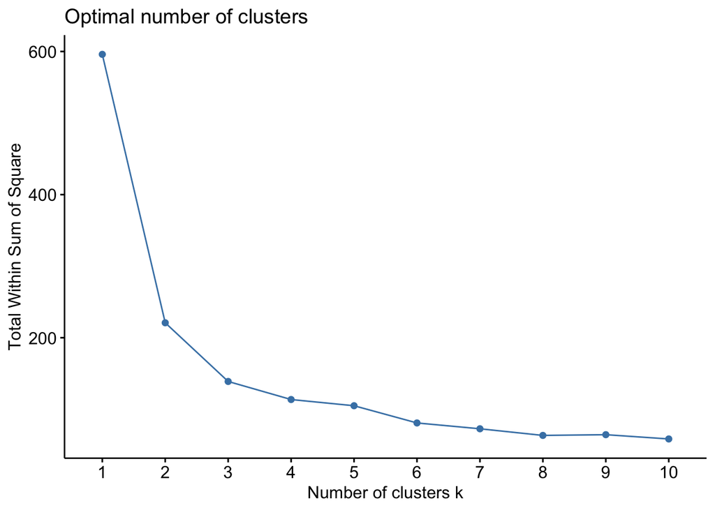

```r
# Plot explained variance vs number of clusters
fviz_nbclust(iris_scaled, kmeans, method='wss')
```

As with the scree plot, this shows us how much additional variance is explained by adding more clusters to K-Means. The optimal number of clusters is found by identifying the ‘elbow’ of the plot, or the point at which adding more clusters does not improve the amount of explained variance by much. Here, the elbow could be 2 or 3, but adding the 3rd cluster contributes much less than the first 2.

Based on this investigation, I might decide to use only 2 clusters, since the 3rd cluster is not really able to find a meaningful separation between species. If we wish to use the 2 clusters in further analyses, we could add them to the original `iris` dataset as follows:

```r
# Create 2 clusters features
iris$Clusters <- iris %>% select(-Species) %>% scale %>% kmeans(centers=2) %>% .$cluster %>% factor

# Check results
iris %>% summary
```

```
##   Sepal.Length    Sepal.Width     Petal.Length    Petal.Width
##  Min.   :4.300   Min.   :2.000   Min.   :1.000   Min.   :0.100
##  1st Qu.:5.100   1st Qu.:2.800   1st Qu.:1.600   1st Qu.:0.300
##  Median :5.800   Median :3.000   Median :4.350   Median :1.300
##  Mean   :5.843   Mean   :3.057   Mean   :3.758   Mean   :1.199
##  3rd Qu.:6.400   3rd Qu.:3.300   3rd Qu.:5.100   3rd Qu.:1.800
##  Max.   :7.900   Max.   :4.400   Max.   :6.900   Max.   :2.500
##        Species   Clusters
##  setosa    :50   1:100
##  versicolor:50   2: 50
##  virginica :50
##
##
##
```

This demonstrates how you can use K-Means to explore structure in your data and engineer new categorical features representing the cluster IDs.

# Concluding remarks

Skillful exploration, data cleaning, and feature engineering is where analysts have the most potential to differentiate themselves. Have the patience to get to know your dataset and treat it with care. It will pay off in the long run!